# Seminarska naloga

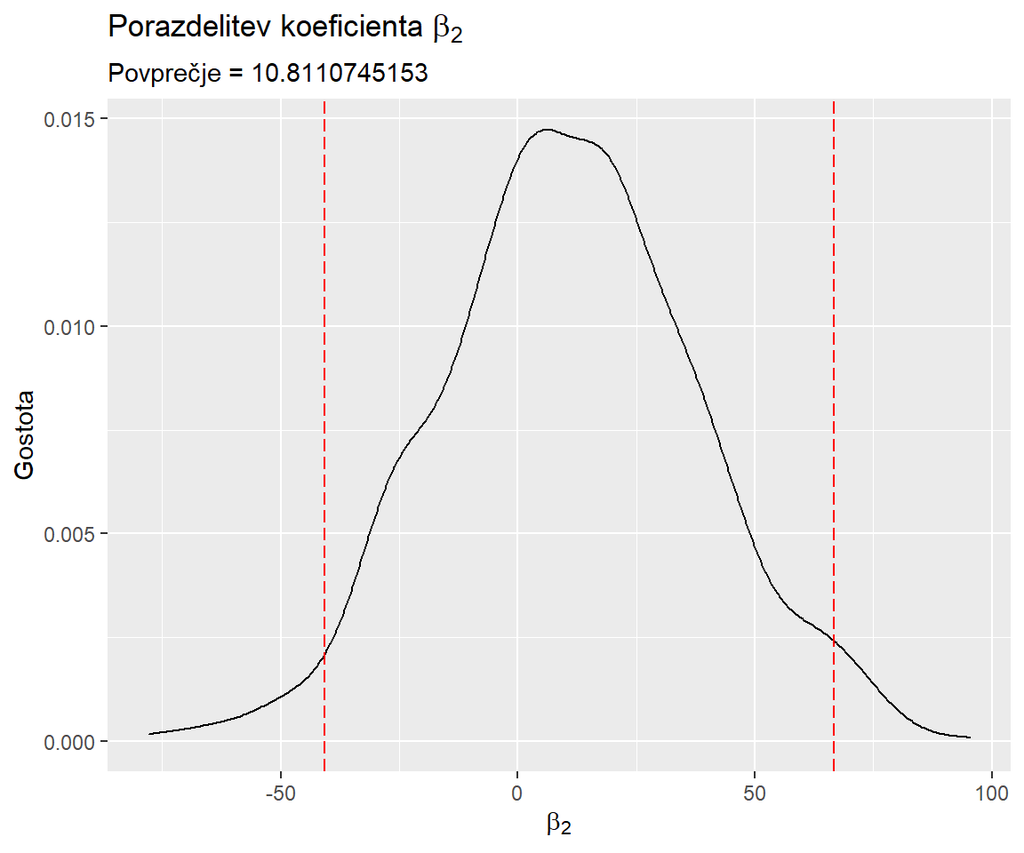

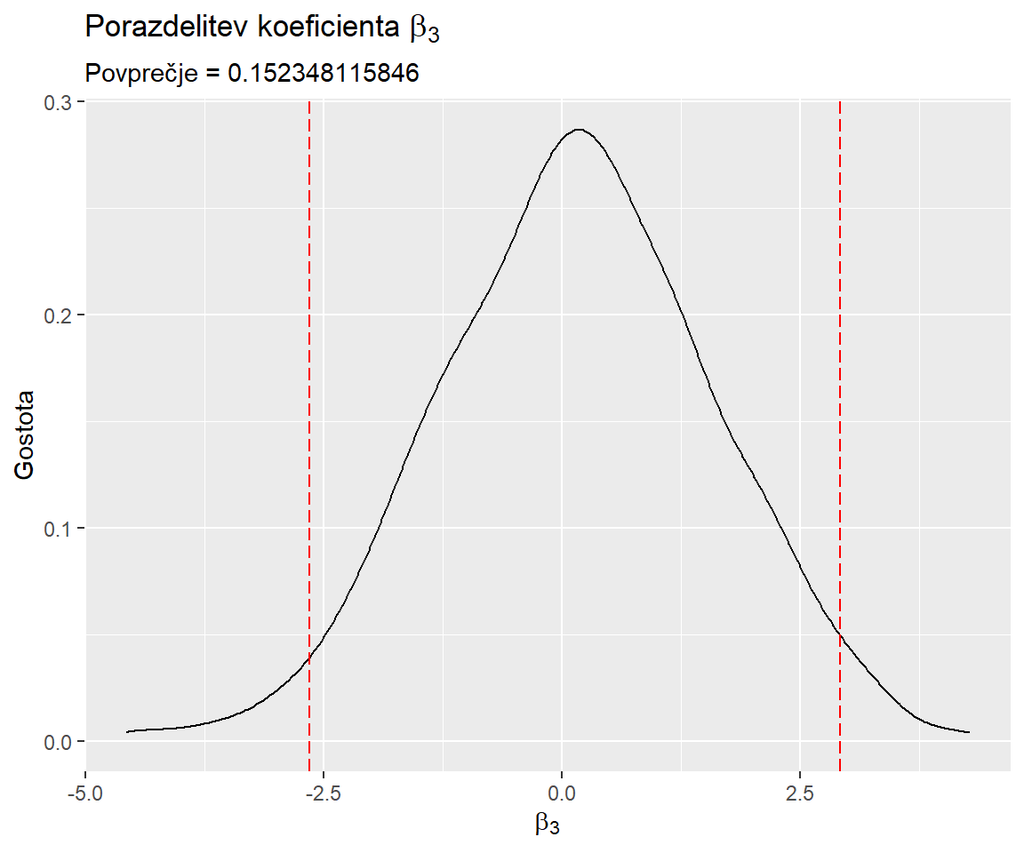

Poglejmo si še tabelo, kjer so zapisane meje in povprečja porazdelitev.

|  | Beta | Povprečje | 2.5% | 97.5% |
| --- | --- | --- | --- | --- |
| (Intercept) | 0 | 23498.05 | 12337.43 | 34596.03 |
| mpg | 1 | 193.38 | -32.83 | 425.48 |
| horsepower | 2 | 10.81 | -40.67 | 66.69 |
| weight | 3 | 0.15 | -2.65 | 2.91 |

# Hierarhični model

Podobno kot prej si bomo ogledovali vrednost spremenljivke *price*, tokrat po modelskem letu. Imamo 13 skupin in sicer za posamično leto med 1970 in 1982. Torej preverjali bomo kako se je *price* spreminjala v času. V spodnji tabeli lahko razberemo velikosti skupin po modelskem letu.

|  | 70 | 71 | 72 | 73 | 74 | 75 | 76 | 77 | 78 | 79 | 80 | 81 | 82 |
| --- | --- | --- | --- | --- | --- | --- | --- | --- | --- | --- | --- | --- | --- |
| št. zapisov | 28 | 27 | 27 | 39 | 26 | 30 | 33 | 28 | 36 | 27 | 26 | 28 | 30 |

Poglejmo si še porazdelitev cene, kjer rdeča črta predstavlja povprečje.

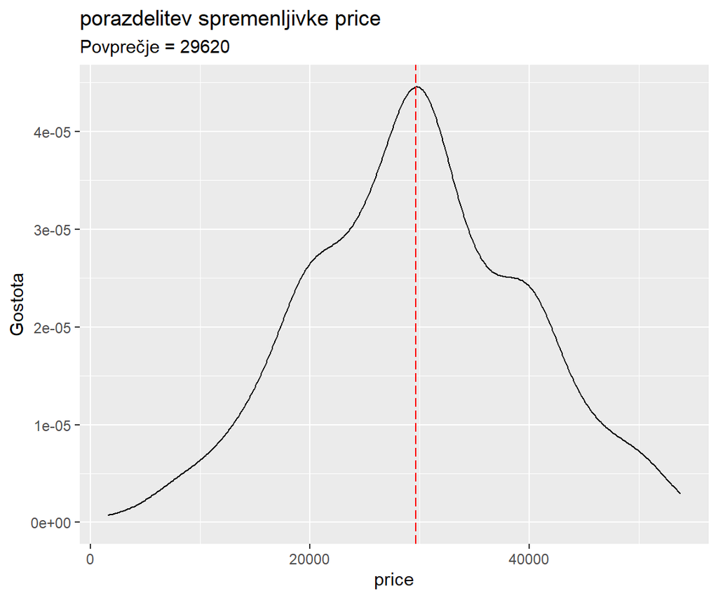

Videti je manjše “stopnice” pri vrednostih $20000$ in $40000$, kar je posledica tega da je veliko cen bilo ravno takšnega zneska. S hierarhičnim modelom bomo poskusili oceniti aposteriorne porazdelitve (hiper)parametrov podobno kot v prejšnji domači nalogi. Takrat so skupine predstavljale šole tokrat pa predstavljajo posamezno modelsko leto. Takrat smo “merili” ocene po šolah, tokrat bomo pa poskusili ovrednotiti ceno po modelskem letu.

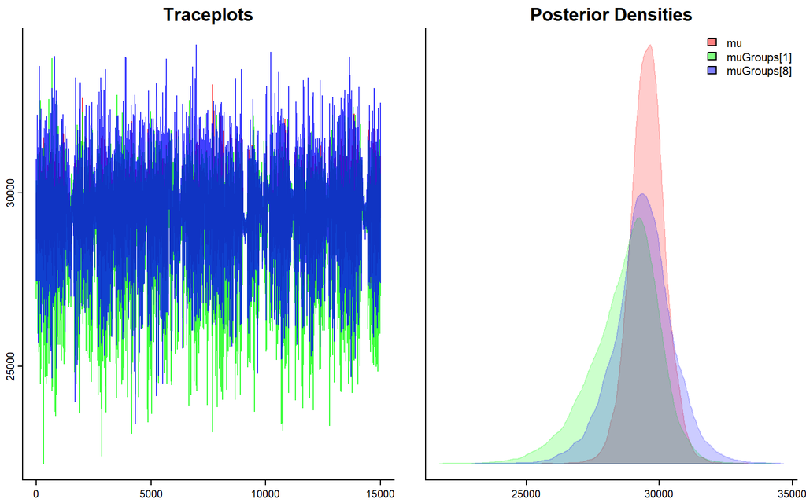

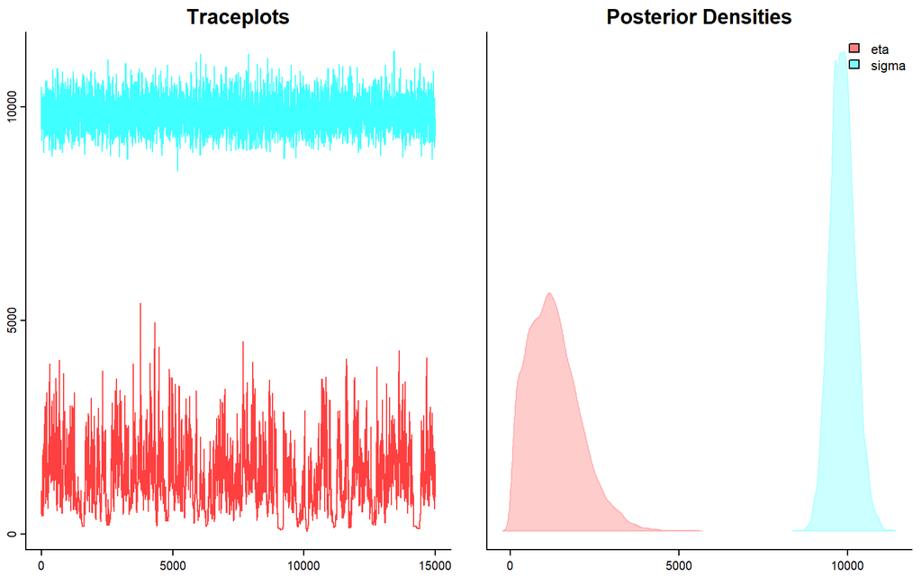

Izgleda da smo dosegli konvergenco v vseh primerih $\mu$, $\eta^2$, $\sigma^2$ in posamezne skupine $\mu_j$. $\mu$ predstavlja skupno povprečje cene, $\eta^2$ predstavlja skupno varianco cene, $\sigma^2$ pa predstavlja varianco cene znotraj modelskega leta. Št. iteracij v MCMC algoritmu je bilo 15000.

Poglejmo si aposteriorne porazdelitve hiperparametrov, kjer so označene mediana in 95% interval zaupanja.

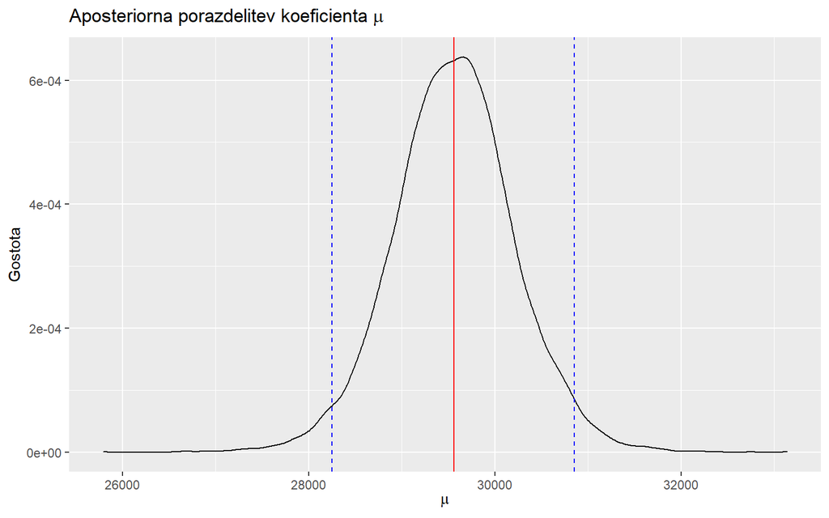

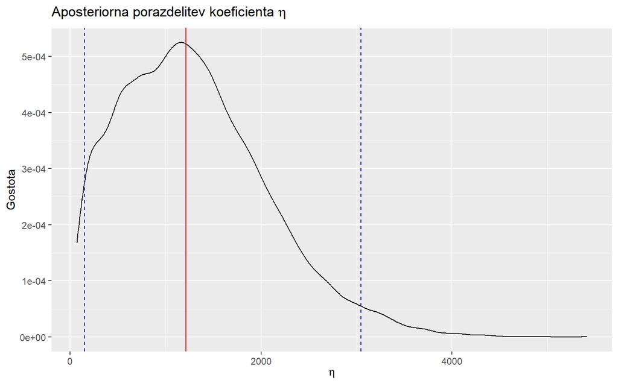

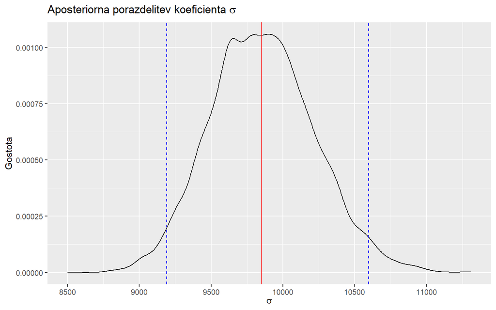

Porazdelitve so pričakovane, vidimo da je mediana $\mu$ nekoliko manj od $30000$ ($29565.67$). Mediane cen po posameznih modelskih letih se gibljejo od $28673$ do $30605$, tako da večjih odstopanj od skupnega povprečja ni videti. Pogledamo si lahko še *effective sample size* ter največjo korelacijo med skupinami.

|  | Effective sample size |
| --- | --- |
| eta | 289.00 |
| mu | 2125.40 |
| muGroups[1] | 1238.95 |
| muGroups[2] | 4320.59 |
| muGroups[3] | 1759.63 |
| muGroups[4] | 2024.90 |
| muGroups[5] | 4602.08 |
| muGroups[6] | 907.15 |
| muGroups[7] | 5318.46 |
| muGroups[8] | 4991.42 |
| muGroups[9] | 493.04 |
| muGroups[10] | 4821.49 |
| muGroups[11] | 674.21 |
| muGroups[12] | 5174.86 |
| muGroups[13] | 3558.36 |
| sigma | 3253.54 |

Pričakoval bi nekoliko višje vrednosti, saj je št. iteracij bilo 15000. Predvsem so nizke za $\eta$ in nekatere $\mu_j$ ($j=1, 6, 9 \ \mathrm{in}\ 11$). Ostali so v najboljšem primeru približno tretjina vseh iteracij. Maksimalna korelacija med parametri je bila 0.57851 kar je še vedno vredu. Tu bi bilo smiselno razmisliti o uporabi drugačnega algoritma če bi bila korelacija nad $0.9$.

Med modelskimi leti vidimo da ni večjih razlik in tako težko rečemo da je modelsko leto bistveno vplivalo na ceno avtomobilov (inflacija, spremembe avtomobilov, itd.).